# 05Functions

Introduction to Programming in Python 2019/2020

Sant'Anna School of Advanced Studies, Pisa, Italy

Course responsible

Andrea Vandin a.vandin@santannapisa.it

Co-lecturer

Daniele Licari d.licari@santannapisa.it

Module 5: Functions

With cool applications to

Analysis of SIR models data and Creation of word clouds for COVID-related online news

Tentative lecture plan

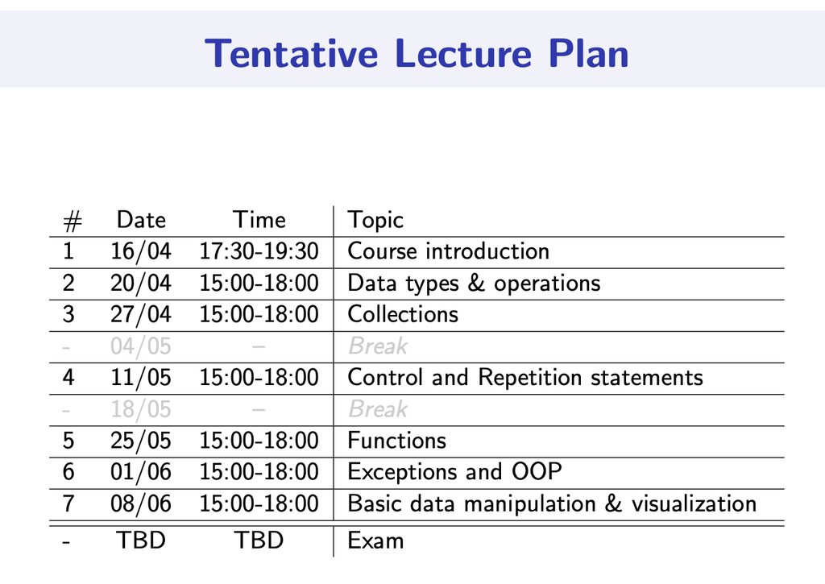

```python
from IPython.display import Image, display
img=Image(filename='images/tentativeLecturePlan.png',width=700)
display(img)
```

How good are we so far - Kahoot quiz on classes 3 and 4

- Using your phone or a different display go to https://kahoot.it/
- Type the given PIN

```python
from IPython.display import IFrame
IFrame("https://kahoot.it/", 500, 400)
```

[interactive chart not shown]

# Intro: copy-pasting is not a good idea when programming

*How to get readable and manutenable code by avoiding spaghetti code*

Let's sum up the first `n` naturals:

```python
sum1 = 0

n = int(input())
rng = range(1,n+1)
for i in rng:
    sum1+=i
print('The sum of the first',n,'naturals',list(rng),'is',sum1)
```

```
The sum of the first 3 naturals [1, 2, 3] is 6
```

## Classic copy-paste errors

What if we want to do this several times in different parts of a program?

- A bugged version due to **classic copy-paste errors**

```python
#BUGGED VERSION DUE TO CLASSIC COPY-PASTE ERRORS
sum1 = 0

n = int(input())
rng = range(1,n+1)
for i in rng:
    sum1+=i
print('The sum of the first',n,'naturals',list(rng),'is',sum1)


# Do something else ...
# Do something else ...
# Do something else ...
# Do something else ...
# Do something else ...
# Do something else ...
# Do something else ...
# Do something else ...
# Do something else ...
# Do something else ...
# Do something else ...
# Do something else ...
# Do something else ...
# Do something else ...
# Do something else ...
# Do something else ...


n2 = int(input())
rng = range(1,n+1)
for i in rng:
    sum1+=i
print('The sum of the first',n,'naturals',list(rng),'is',sum1)
```

```
The sum of the first 3 naturals [1, 2, 3] is 6
```

```
The sum of the first 3 naturals [1, 2, 3] is 12
```

```python
#FIXED VERSION
sum1 = 0

n = int(input())
rng = range(1,n+1)
for i in rng:
    sum1+=i
print('The sum of the first',n,'naturals',list(rng),'is',sum1)


# Do something else ...
# Do something else ...
# Do something else ...
# Do something else ...
# Do something else ...
# Do something else ...
# Do something else ...
# Do something else ...
# Do something else ...
# Do something else ...
# Do something else ...
# Do something else ...
# Do something else ...
# Do something else ...
# Do something else ...
# Do something else ...


sum1=0
n2 = int(input())
rng = range(1,n2+1)
for i in rng:
    sum1+=i
print('The sum of the first',n2,'naturals',list(rng),'is',sum1)
```

```
The sum of the first 3 naturals [1, 2, 3] is 6
```

```
The sum of the first 4 naturals [1, 2, 3, 4] is 10
```

Imagine doing this in a file with thousands of lines of code and several copies of the same code

- It would be very error-prone!

Luckily, we can wrap this computation **in a function**

- **Defined** (written) once
- **Invoked** (used, called) many times

```python
def sumNaturals(n):
    sum1 = 0
    rng = range(1,n+1)
    for i in rng:
        sum1+=i
    print('The sum of the first',n,'naturals',list(rng),'is',sum1)
    return sum1

sum3 = sumNaturals(3)
sum4 = sumNaturals(4)
print('Twice the sum of the first 4 naturals:',sum4*2)
```

```
The sum of the first 3 naturals [1, 2, 3] is 6
The sum of the first 4 naturals [1, 2, 3, 4] is 10
Twice the sum of the first 4 naturals: 20
```

```python
sumNaturals(int(input()))
sumNaturals(int(input()))
```

```
The sum of the first 3 naturals [1, 2, 3] is 6
```

```
The sum of the first 3 naturals [1, 2, 3] is 6
```

```
6
```

## Functions increase Modularity and Manutenability

What if we want to update a function?

- Maybe you know that  
  $\sum\limits_{i=1}^{n} i = \frac{(n\cdot n+1)}{2}$
- Above we can just **modify the function once**, and all the rest of the code will become aware of the change

```python
def sumNaturals(n):
    sum1 = int(n*(n+1)/2)
    print('The sum of the first',n,'naturals is',sum1)
    return sum1
```

# What is a function?

[Functions](https://www.w3schools.com/python/python_functions.asp) (in certain cases called procedures) are a key notion in programming

- Enable the **procedural programming style** mentioned in the first class
  - Break down a big problem into smaller ones
  - Decouple
    - the program logic (what the program does) from
    - the data (what the program manipulates)
  - Therefore increase readability and manutenability of programs

A function consists of a set of statements (or instructions) that

- have been collected together
- have been given a name

A bit like in mathematics (e.g. $x1= max(x2,x3)$), functions

- might have arguments ($x_2,x_3$, the **arguments** or **parameters**)
- execute a number of computations based on the arguments (the statements composing its **body**)
- might return a computed value (the **return value**)

But in programming languages:

- Functions might have side effects
  - e.g., can depend on and modify variables defined elsewhere

```python
gv=0

def non_mathematical_function(y):
    print(gv+y)

non_mathematical_function(1)
gv+=1
non_mathematical_function(1)
gv+=1
non_mathematical_function(1)
```

```
1
2
3
```

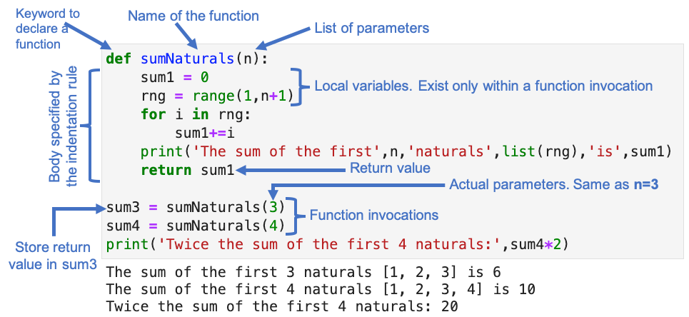

```python
from IPython.display import Image, display
img=Image(filename='images/function.png',width=900)
display(img)
```

**Aspects to consider when writing a function**

- Each function should have a single purpose
  - Can you describe what it does with a single verb?
  - If a function has more purposes, consider to split it
- Use self-commenting names for function and for arguments
  - Something like `def my_fun(my_arg)` is not a good idea
- Do not change mutable arguments (lists, dictionaries, sets)
  - Unless clearly defined, e.g. in the function name
  - You might have *bad surprises* when reusing some old code of yours...

# Scope of variables (Global variables vs Local variables)

```python
def sumNaturals(n):
    sum1 = 0
    rng = range(1,n+1)
    lv = 3
    for i in rng:
        sum1+=i
    print('The sum of the first',n,'naturals',list(rng),'is',sum1)
    return sum1

result = sumNaturals(5)
print('Result contains',result)
print('sum1   contains',sum1)
#print(lv) #This gives an error
```

```
The sum of the first 5 naturals [1, 2, 3, 4, 5] is 15
Result contains 15
sum1   contains 10
```

I just told you that local variables are local to each function invocation

- Therefore we get an error (*NameError: name 'lv' is not defined*)
- But then why can I print `sum1`?
- And why do I get a number different than `15`?

> Because I am printing another variable named `sum1`, a **global variable**, that we have declared above
> - A **global variable** does not belong to any function and exists across all code.
>   - But cannot be used in functions that define a new variable with same nae
> - Everytime we invoke `sumNaturals` we create a new local variable `sum1` which
>   - *shadows* the global variable `sum1`
>   - ceases to exists when the function terminates, making the global variables accessible again.

In general, **global variables are bad if used in functions**!

- Try to minimise their use in functions
- A function should be a self-contained unit of logic
  - If you really need a to reference/modify global variables, try to rethink your code

Python tries to defend us from the problems given by global variables by

- having a *bizarre behaviour* when it comes to global variables used in functions:
1. If you want to use the value of a global variable, you just use the variable
2. If you try to assign a new value to a global variable, you automatically create a new local variable with same name
3. If you really want to modify a global variable `gv` within a function, then you have to prove that you know what you are doing
   - You have to redeclare the global variable `gv` in the function using `global gv`
   - Which means: *hey, I know that gv is a global variable*

```python
gv=0

def global_var_and_function1():
    #No problems in reading the value of the global variable gv
    print(gv)

def global_var_and_function2():
    #No problems in reading the value of the global variable gv
    print(gv)
    #The following statement will create a new local variable named gv which shadows the global variable gv
    #Therefore the print will fail because the local variable gv has not been initialized yet
    gv=1

def global_var_and_function3():
    #The following statement will create a new local variable named gv which shadows the global variable gv
    #Therefore the print will fail because the local variable gv has not been initialized yet
    gv=10
    #No problems in using the local variable gv
    print('gv inside global_var_and_function3() is',gv)

def global_var_and_function4():
    #Dear Python, I want to use and modify the global variable gv
    global gv
    #No problems in reading the value of the global variable gv
    print(gv)
    #The following statement will modify the global variable named gv
    gv+=1

print('global_var_and_function1()')
global_var_and_function1()
gv+=1
global_var_and_function1()

#print('\nglobal_var_and_function2()')
#global_var_and_function2() # ERROR

print('\ngv before global_var_and_function3() is',gv)
global_var_and_function3()
print('gv after global_var_and_function3() is',gv)

print('\nglobal_var_and_function4()')
# global_var_and_function4()
# global_var_and_function4()
# global_var_and_function4()
```

```
global_var_and_function1()
0
1

gv before global_var_and_function3() is 1
gv inside global_var_and_function3() is 10
gv after global_var_and_function3() is 1

global_var_and_function4()
```

## A recap on variables scope

[The scope of a variable refers to the places that you can see or access a variable](https://matthew-brett.github.io/teaching/global_scope.html)

- A variable defined at the top level of your script (e.g. not in a function), is a **global variable**
  - You can access global variables from anywehere in your script
- A variable defined in a function is local to that function
  - Statements in other functions or in the top level of your script cannot see it

# Input and output of a function

## Pass by reference

In Python, arguments are passed **by reference**

- For example, if you pass a list `lst` as argument:
  - The function will not use a copy of `lst`, but `lst` itself (possibly through a variable with different name)
  - Any modification to the list will be reflected in the code that called the function

Intuitively, you pass a *reference to the list*

> Passing an empty list or a list with 1000 elements has the same cost!  
> You pass just the reference to the 'beggining of the list

```python
def append_to_list(lst):
    lst.append('end')

mylst = ["first","second"]
print(mylst)
append_to_list(mylst)
print(mylst)
```

```
['first', 'second']
['first', 'second', 'end']
```

What happens if you execute the code below?

- More importantly: why?

```python
def append_to_list(lst):
    lst.append('end')
    lst = [1,2]
    print('Inside  the function',lst)

mylst = ["first","second"]
print('Before the function',mylst)
append_to_list(mylst)
print('After the function',mylst)
```

```
Before the function ['first', 'second']
Inside  the function [1, 2]
After the function ['first', 'second', 'end']
```

## Arguments can be specified in several ways/with several optiona

### We can specify arguments by name

```python
def print_names(name1,name2):
    print(name1,name2)

print_names('Andrea','Diego')
print_names(name1='Andrea',name2='Diego')
print_names(name2='Diego',name1='Andrea')
```

```
Andrea Diego
Andrea Diego
Andrea Diego
```

### We can make arguments optional providing default values

```python
def print_names(name1,name2):
    print(name1,name2)
print_names('Andrea','Diego')
#print_names('Andrea') #Error!
```

```
Andrea Diego
```

```python
def print_names(name1,name2="NoName"):
    print(name1,name2)
print_names('Andrea','Diego')
print_names('Andrea') #That's fine now!
```

```
Andrea Diego
Andrea NoName
```

```python
def print_names(name1="NoName1",name2="NoName2"):
    print(name1,name2)
print_names('Andrea')
print_names(name2='Diego')
```

```
Andrea NoName2
NoName1 Diego
```

### We can specify that we expect *some* parameters

```python
def print_names(*names):
    for name in names:
        print(name)
    print()
print_names('Andrea')
print_names('Andrea','Diego')
print_names('Andrea','Diego','Matteo')
```

```
Andrea

Andrea
Diego

Andrea
Diego
Matteo
```

### We can specify dictionaries of parameters

```python
def print_names(**params):
    for key, value in params.items():
        print('key is',key,'value is',value)
    print()
print_names(n1 = 'Andrea')
print_names(n1 = 'Andrea' , n2 = 'Diego')
print_names(n1='Andrea',n2='Diego',n3='Matteo')
```

```
key is n1 value is Andrea

key is n1 value is Andrea
key is n2 value is Diego

key is n1 value is Andrea
key is n2 value is Diego
key is n3 value is Matteo
```

## The return value of a function

A function terminates when

- The last statement in its body is executed
- A `return` statement is executed

```python
def testReturn():
    print('This will be printed')
    return
    print('This will NOT be printed')

testReturn()
```

```
This will be printed
```

As we have seen above, `return` can be used to let the function produce an output

- The result of the computation in the function
- Returned to the caller of the function

```python
def sumNaturals(n):
    sum1 = int(n*(n+1)/2)
    return sum1

computed_value = sumNaturals(5)
print('The function computed',computed_value)
```

```
The function computed 15
```

# Everything is an object, even functions

As we discussed in the first class, everything is an object in Python, even functions.

We can

- assign functions to variables
- we can pass functions as arguments to other functions

```python
def my_sum(n1,n2):
    return n1+n2
def my_mul(n1,n2):
    return n1*n2

#Expr is a variable referring to the function my_sum
expr = my_sum
print(type(expr))
print(expr(1,2))

expr = my_mul
print(expr(1,2))
```

```
<class 'function'>
3
2
```

Therefore functions can even be used as arguments of other functions

```python
def expression_evaluator(f,n1,n2):
    print(f(n1,n2))

expression_evaluator(my_sum,1,2)
expression_evaluator(my_mul,1,2)
```

```
3
2
```

# Functions and libraries

Functions can be seen as

- an *interface* or a *contract*

```python
#Function name and arguments
def sumNaturals(n):
    #Actual computation
    sum1 = 0
    rng = range(1,n+1)
    for i in rng:
        sum1+=i
    #return computed value
    return sum1

#Function name and arguments
def sumNaturals(n):
    #Actual computation
    sum1 = int(n*(n+1)/2)
    #return computed value
    return sum1
```

We saw two versions of `sumNaturals`. Both

1. take an argument `n`
2. compute the sum of the first `n` naturals
3. return the computed sum

What changes in the two implementations is how step 2 is implemented

- But developers do not necessarily need to know what precisely happens in point 2.
  - They only need to know what to feed in, and what to expect in output
- This allows to split the complexity of a program into several smaller problems, possibly solved by others
  - Luckily I don't need to know how strings are converted into int when using `int()`...

A **library** like *matplotlib* or *csv* is nothing more than a collection of

- types
- functions defined in other files

# An application to data from a simple SIR model

## A simple SIR model in ERODE

You probably heard a lot about

- SIR model
- R_0

[A SIR model](https://en.wikipedia.org/wiki/Compartmental_models_in_epidemiology), in its simplest form, is a model with 3 variables

- **S**usceptible
- **I**nfected
- **R**ecovered

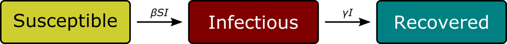

```python
from IPython.display import Image, display
img=Image(filename='images/SIR_Flow_Diagram.png',width=800)
display(img)
```

From [this wikipedia page](https://en.wikipedia.org/wiki/Compartmental_models_in_epidemiology)

More precisely, the classic SIR model is expressed as

[figure not shown]

```python
from IPython.display import Image, display
img=Image(filename='images/SIRerode.png',width=1200)
display(img)
```

This is a screenshot of my own tool [ERODE](https://www.erode.eu/) able to analyse Reaction Networks and ODEs

```python
from IPython.display import IFrame
IFrame("http://www.erode.eu/", 1000, 1000)
```

[interactive chart not shown]

Now, it is known that R_0 is given by

- R_0 = beta/gamma

In ERODE we can play with these parameters and see what happens. The figure above shows the plots for

- Bottom-Left: R_0=0.25 (beta=1,gamma=4)
- Bottom-Right: R_0=2.00 (beta=1,gamma=0.5)

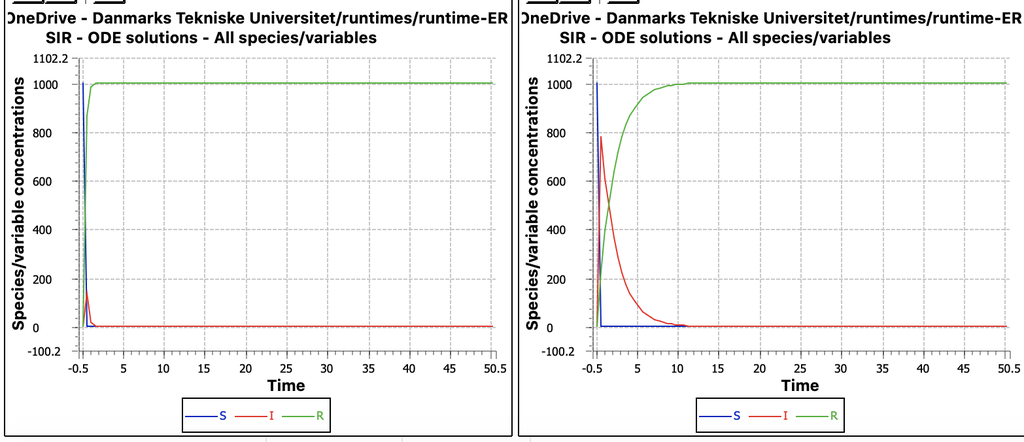

```python
from IPython.display import Image, display
img=Image(filename='images/SIRerodeJustPlots.png',width=900)
display(img)
```

In ERODE, we actually created plots for

- R_0=0.25 (beta=1,gamma=4)
- R_0=0.50 (beta=1,gamma=2)
- R_0=1.00 (beta=1,gamma=1)
- R_0=2.00 (beta=1,gamma=0.5)

## Let's do some plots using these data

```python
#import sys
#!{sys.executable} -m pip install matplotlib
#import sys
#!{sys.executable} -m pip install csv
```

```python
import csv
import matplotlib.pyplot as plt
```

### We first replicate one of the plots generated by ERODE

First I load the data for the case R_0 = 0.25

```python
fileName='csv/SIR_ERODE/sirR0_0.25.cdat'

#I want to 'open' a csvfile to 'r'ead it
#  For the time being, ignore the with statement.
#  Assume it does: csv = open(fileName, 'r')
#  I will tell you more on this in two classes from now
with open(fileName, 'r') as csvfile:
    #Intuitively,
    #  `csv` allows us to read csv files row by row.
    #  `rows` is a list of rows in the file.
    #   Each row is in turn a list of strings containing one entry per column
    rows = csv.reader(csvfile, delimiter=',')

    #We load the header of the file in the list `header`
    labels = next(rows,None)
    #print(labels)

    #We now iterate over all rows to load the data
    time = []
    S = []
    I = []
    R = []
    #We put these lists in another list to simplify the for loop below
    loaded_data = [time,S,I,R]

    for row in rows :
        #print(row)
        for column in range(len(loaded_data)):
            data = row[column]
            datafloat = float(data)
            datafloatRound = round(datafloat,4)
            loaded_data[column].append(datafloatRound)
            #print(data,float(data))

#print(loaded_data)
```

Then I recreate ERODE's plot for the case R_0=0.25

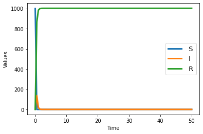

```python
x = loaded_data[0]

for i in range(1,len(loaded_data)) :
    plt.plot(x,loaded_data[i], label=labels[i],linewidth=3)

plt.legend(fontsize=13)
plt.xlabel('Time')
plt.ylabel('Values')

#plt.savefig('SIR model',bbox_inches='tight')
plt.show()
```

## Let's create a plot where we compare how the Infected population evolves in the 4 scenarios

For doing this, we need to do more or less the same tasks done for the previous plot

- But this time we have to do it 4 times. Once per different R_0 value
- Let's use functions!

```python
def loadSIRCSV(file_name):
    #I want to 'open' a csvfile to 'r'ead it
    #  For the time being, ignore the with statement.
    #  Assume it does: csv = open(fileName, 'r')
    #  I will tell you more on this in two classes from now
    with open(file_name, 'r') as csvfile:
        #Intuitively,
        #  `csv` allows us to read csv files row by row.
        #  `rows` is a list of rows in the file.
        #   Each row is in turn a list of strings containing one entry per column
        rows = csv.reader(csvfile, delimiter=',')

        #We load the header of the file in the list `header`
        labels = next(rows,None)
        #print(labels)

        #We now iterate over all rows to load the data
        time = []
        S = []
        I = []
        R = []
        #We put these lists in another list to simplify the for loop below
        loaded_data = [time,S,I,R]

        for row in rows :
            #print(row)
            for column in range(len(loaded_data)):
                data = row[column]
                datafloat = float(data)
                datafloatRound = round(datafloat,4)
                loaded_data[column].append(datafloatRound)
                #print(data,float(data))
    return loaded_data
```

Thanks to this function, now it is very easy to load the four CSV files generated by ERODE

```python
loaded_data0_25 = loadSIRCSV('csv/SIR_ERODE/sirR0_0.25.cdat')
loaded_data0_50 = loadSIRCSV('csv/SIR_ERODE/sirR0_0.50.cdat')
loaded_data1_00 = loadSIRCSV('csv/SIR_ERODE/sirR0_1.00.cdat')
loaded_data2_00 = loadSIRCSV('csv/SIR_ERODE/sirR0_2.00.cdat')
```

We now create 3 plots, each comparing:

- the susceptible population in the four configurations
- the infected population in the four configurations
- the recovered population in the four configurations

Of course, we are going to use a function to do this

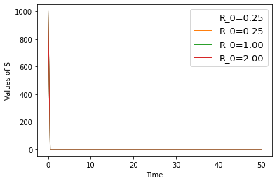

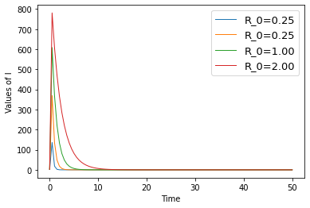

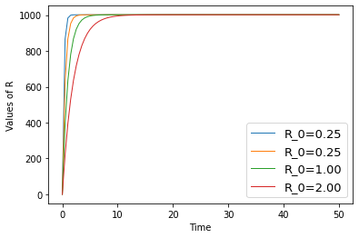

```python
def plot_population(all_data,config_names,pop_id,pop_name):
    for i in range(len(all_data)) :
         plt.plot(all_data[i][0],all_data[i][pop_id], label=config_names[i],linewidth=1)
    plt.legend(fontsize=13)
    plt.xlabel('Time')
    plt.ylabel('Values of '+pop_name)
    plt.show()


all_data = [loaded_data0_25,loaded_data0_50,loaded_data1_00,loaded_data2_00]
config_names = ['R_0=0.25','R_0=0.25','R_0=1.00','R_0=2.00']
plot_population(all_data,config_names,1,'S')
plot_population(all_data,config_names,2,'I')
plot_population(all_data,config_names,3,'R')
#print(type(all_data))
#print(len(all_data))
```

# An application the creation of word clouds for COVID-related online news

This topic is treated in the jupyter notebook available [here](https://raw.githubusercontent.com/andrea-vandin/IntroToPython20192020/master/jupyter/jupyterNotebooks/05WordCloudCovid.ipynb)

# Lambda functions, map, filter and reduce

## Lambda functions

**[Lambda functions](https://www.w3schools.com/python/python_lambda.asp)**: in some cases, it might be convenient to define on-the-fly anonymous simple functions

- **anonymous**: the function has no name
- **simple**: the function can consist only of one expression

This lambda function computes the sum of two numbers: `lambda a, b: a+b`

```python
my_lfun = lambda a, b: a+b
my_lfun(1,2)
```

```
3
```

```python
def expression_evaluator(f,n1,n2):
    print(f(n1,n2))

expression_evaluator(lambda a, b: a+b, 1,2)
```

```
3
```

A lambda function is really nothing more than a simple function without name

- Why should we use them then?

There are places where `def` cannot be used:

- In arguments of functions or in return statements

Lambda expression can help you avoiding annoying workarounds

- In the end, it is just syntactic sugar

```python
# Python closures and lambda expressions
#    We attach data to code
def myfunc(n):
  return lambda a : a * n

mydoubler = myfunc(2)
mytripler = myfunc(3)

print(mydoubler(11))
print(mytripler(11))
```

```
22
33
```

```python
#This cannot be done
# def myfunc(n):
#   return def aaa(a) :
#             a * n
```

However you can do

```python
def myfunc(n):
    def myinnerfunc(a) :
        return a * n
    return myinnerfunc

mydoubler2 = myfunc(2)
mytripler2 = myfunc(3)

print(mydoubler(11))
print(mytripler(11))
```

```
22
33
```

Lambda functions are typically used in conjunction with

- **map**: applies a given function to each element in a sequence
- **filter**: applies a Boolean function to each element in a sequence, and returns only those evaluated to `true`
- **reduce**: applies cumulatively a given function to the elements in a sequence, and return the cumulative result

Notes:

- In the examples below we will define functions. But any Python function can be used, even built-in ones.
- In the examples below, the functions take 1 parameter. If the considered functions have 2, 3, or more parameters, you just have to provide 2, 3, or more lists.

Some examples have been taken from the two following links, where interesting discussions on lambdas, map, filter, and reduce can be found:

- [Reference 1](https://book.pythontips.com/en/latest/map_filter.html#map-filter-and-reduce)
- [Reference 2](https://www.learnpython.org/en/Map,_Filter,_Reduce)

## Map

```python
items = [1, 2, 3, 4, 5]

#Using a loop
squared = []
for i in items:
    squared.append(i**2)
print(squared)

#Can be expressed more compactly using maps
squared = list(map(lambda x: x**2, items))
print(squared)

#The same you can do with list comprehensions
squared = [x**2 for x in items]
print(squared)
```

```
[1, 4, 9, 16, 25]
[1, 4, 9, 16, 25]
[1, 4, 9, 16, 25]
```

You can even have list of functions rather than a list of values

```python
def multiply(x):
    return (x*x)
def add(x):
    return (x+x)

funcs = [multiply, add]
for i in range(5):
    value = list(map(lambda x: x(i), funcs))
    print(value)
```

```
[0, 0]
[1, 2]
[4, 4]
[9, 6]
[16, 8]
```

Another example using a built-in function

```python
names = ['andrea','daniele']
capitalized_names = list(map(str.capitalize,names))
print(capitalized_names)
```

```
['Andrea', 'Daniele']
```

## Filter

```python
items = [1, 2, 3, 4, 5]

#Using a loop
odd_numbers = []
for i in items:
    if i%2 !=0 :
        odd_numbers.append(i)
print(odd_numbers)

#Can be expressed more compactly using maps
odd_numbers = list(filter(lambda x: x%2 != 0, items))
print(odd_numbers)

#The same you can do with list comprehensions
odd_numbers = [x for x in items if x%2 !=0]
print(odd_numbers)
```

```
[1, 3, 5]
[1, 3, 5]
[1, 3, 5]
```

## Reduce

```python
items = [1, 2, 3, 4, 5]

#Using a loop
tot_sum = 0
for i in items:
    tot_sum += i
print(tot_sum)

#Can be expressed more compactly using maps
from functools import reduce
tot_sum = reduce(lambda x, y: x + y, items)
print(tot_sum)

#The result is not a list but a number, therefore you can't use comprehensions
```

```
15
15
```

Reduce works as follow:

- Initially, `x` and `y` are the first and second element of the list, resp
- In every following step, `x` is cumulative value computed so far, while `y` is the next element in the list

Of course you can combine all map, filter and reduce

```python
items = [1, 2, 3, 4, 5]

squared = map(lambda x: x**2, items)
squared_smaller_than_ten = filter(lambda x: x<10, squared)
sum_of_squared_smaller_than_ten = reduce(lambda x, y: x + y, squared_smaller_than_ten)
print(sum_of_squared_smaller_than_ten)

#Can be expressed in one go
sum_of_squared_smaller_than_ten = reduce(lambda x, y: x + y,filter(lambda x: x < 10, map(lambda x: x**2, items)))
print(sum_of_squared_smaller_than_ten)
```

```
14
14
```

## A closing note on map, filter and reduce

- These are notions typical of so-called *functional programming languages*
  - Languages somehow close to the mathematical language/mathematical way of thinking,
  - Everything is a function, and computation evolves by evaluating the correct functions
- They don't enrich the expressive power of Python
  - But they allow you to write more compact code avoiding loops and if.
- They became mainstream (supported e.g. in Java or .NET languages) about 5/10 years ago

My personal opinion:

- These are advanced programming features that you might not need (and might not understand :D ) as comprehensions should be enough for most of your problems
- Performance-wise, they are not so different.
- Nevertheless, you might encounter them when googling for a solution for a problem
- Therefore you should know them, while I suggest you to use comprehensions whenever possible